# Homework 6

DATS 6101 · Fall 2026

Sam Nicholes

2026-11-15

```r
# Fifty countries, each variable averaged over 1960 to 1970.
life <- LifeCycleSavings

# Body weight (kg) and brain weight (g) for 62 species.
data(mammals, package = "MASS")


# The spread ratio: residual SD in the top third of fitted values --------------
# over the bottom third. Near 1 means the spread is even.
spread_ratio <- function(m) {
  third <- cut(fitted(m), quantile(fitted(m), 0:3 / 3), include.lowest = TRUE)
  s <- tapply(resid(m), third, sd)
  s[[3]] / s[[1]]
}

# Output -----------------------------------------------------------------------
# ≈ 1   Residual spread is similar across the range of predictions, consistent with constant variance
# > 1   Spread grows as predictions grow (the classic “fan” or “funnel” shape in a residuals-vs-fitted plot)
# < 1   Spread shrinks as predictions grow (a reversed funnel)
```

# Part 1 · Reading a model with four predictors (14 points)

### Model

Savings Rate is regressed onto % of population under 15; % of population over 75; disposable income per person; and growth rate

```r
full <- lm(sr ~ pop15 + pop75 + dpi + ddpi, data = LifeCycleSavings)
summary(full)
```

```
##
## Call:
## lm(formula = sr ~ pop15 + pop75 + dpi + ddpi, data = LifeCycleSavings)
##
## Residuals:
##     Min      1Q  Median      3Q     Max
## -8.2422 -2.6857 -0.2488  2.4280  9.7509
##
## Coefficients:
##               Estimate Std. Error t value Pr(>|t|)
## (Intercept) 28.5660865  7.3545161   3.884 0.000334 ***
## pop15       -0.4611931  0.1446422  -3.189 0.002603 **
## pop75       -1.6914977  1.0835989  -1.561 0.125530
## dpi         -0.0003369  0.0009311  -0.362 0.719173
## ddpi         0.4096949  0.1961971   2.088 0.042471 *
## ---
## Signif. codes:  0 '***' 0.001 '**' 0.01 '*' 0.05 '.' 0.1 ' ' 1
##
## Residual standard error: 3.803 on 45 degrees of freedom
## Multiple R-squared:  0.3385, Adjusted R-squared:  0.2797
## F-statistic: 5.756 on 4 and 45 DF,  p-value: 0.0007904
```

## (1a) The coefficient on pop15

```r
a1_coeff <- full$coefficients["pop15"]
a1_se <- summary(full)$coefficients["pop15", "Std. Error"]
a1_ci <- confint(full, "pop15")
a1_pval <- summary(full)$coefficients["pop15", "Pr(>|t|)"]
a1_rsq <- summary(full)$r.sq
a1_rse <- sigma(full)
```

The coefficient for `pop15` is -0.461. One percentage unit increase in `pop15` for a given country is associated with a decrease of 0.461 percentage points in saving rate, holding `pop75`, `dpi`, and `ddpi` constant. The SE for `pop15` is 0.145, with a 95% CI of -0.753, -0.17, and p-value of 0.003; indicating that the coefficient is significant.

## (1b) The coefficient on pop75

```r
b1_coeff <- full$coefficients["pop75"]
b1_se <- summary(full)$coefficients["pop75", "Std. Error"]
b1_ci <- confint(full, "pop75")
b1_pval <- summary(full)$coefficients["pop75", "Pr(>|t|)"]
```

The coefficient for `pop75` is -1.691 (CI: -3.874, 0.491, p = 0.126) holding all other covariates constant. Any association between `pop75` and savings rate is not significant for this data. Since it has a large CI whose range is negative to positive, it cannot reliably tell us the direction of the association. At the very least, a positive association will not be large.

## (1c) What “holding constant” means here

Holding covariates constant means to hold the values for those covariates constant in the model while allowing a given predictor to vary to determine its association with the outcome and provide an estimate coefficient. It does not describe a comparison among countries, but that for a given country the estimate can be observed given the data. “A percentage point increase in `pop15` results in a 0.461 percentage point decrease in savings rate.” A causal sentence like this is not supported by the data as the study design is observational only.

# Part 2 · Two predictors that move together (16 points)

## (2a) The correlation and the VIFs

```r
cor_pop <- cor(x = life$pop15, y = life$pop75)
cor_pop
```

```
## [1] -0.9084787
```

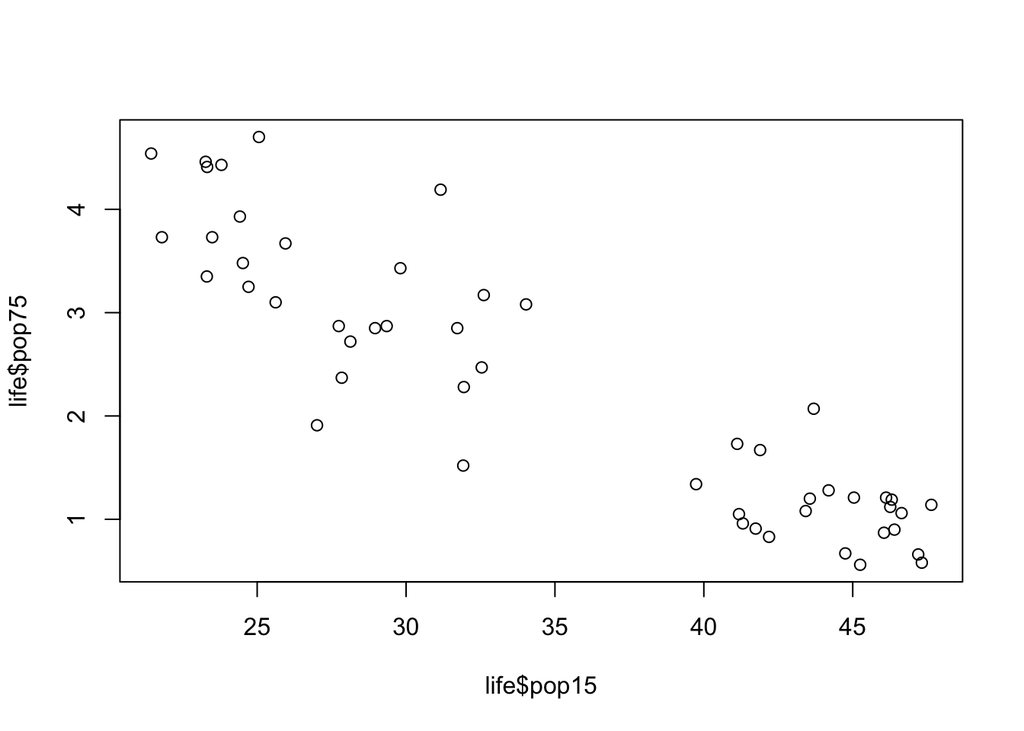

```r
plot(life$pop15, life$pop75)
```

```r
vif_values <- vif(full)
vif_values
```

```
##    pop15    pop75      dpi     ddpi
## 5.937661 6.629105 2.884369 1.074309
```

```r
vif_rsq <- 1 - (1/vif_values)
vif_rsq * 100
```

```
##     pop15     pop75       dpi      ddpi
## 83.158352 84.915008 65.330375  6.916874
```

The correlation between `pop15` and `pop75` is -0.908.

VIFs for each covariate:

- `pop15`: 5.938
- `pop75`: 6.629
- `dpi`: 2.884
- `ddpi`: 1.074

## (2b) Without pop75

```r
full_mod2 <- lm(sr ~ pop15 + dpi + ddpi, data = LifeCycleSavings)
summary(full_mod2)
```

```
##
## Call:
## lm(formula = sr ~ pop15 + dpi + ddpi, data = LifeCycleSavings)
##
## Residuals:
##     Min      1Q  Median      3Q     Max
## -7.6889 -2.8813  0.0296  1.7989 10.4330
##
## Coefficients:
##               Estimate Std. Error t value Pr(>|t|)
## (Intercept) 19.2771687  4.3888974   4.392 6.53e-05 ***
## pop15       -0.2883861  0.0945354  -3.051  0.00378 **
## dpi         -0.0008704  0.0008795  -0.990  0.32755
## ddpi         0.3929355  0.1989390   1.975  0.05427 .
## ---
## Signif. codes:  0 '***' 0.001 '**' 0.01 '*' 0.05 '.' 0.1 ' ' 1
##
## Residual standard error: 3.862 on 46 degrees of freedom
## Multiple R-squared:  0.3026, Adjusted R-squared:  0.2572
## F-statistic: 6.654 on 3 and 46 DF,  p-value: 0.0007941
```

```r
# Stats from model 2
b2_coeff <- full_mod2$coefficients["pop15"]
b2_se <- summary(full_mod2)$coefficients["pop15", "Std. Error"]
b2_ci <- confint(full_mod2, "pop15")
b2_pval <- summary(full_mod2)$coefficients["pop15", "Pr(>|t|)"]
b2_rsq <- summary(full_mod2)$r.sq
b2_rse <- sigma(full_mod2)
```

| **Statistic** | **Model 1** | **Model 2** |
| --- | --- | --- |
| Coefficient | -0.461 | -0.288 |
| Std Error | 0.145 | 0.095 |
| 95% CI | -0.753, -0.17 | -0.479, -0.098 |
| P-Value | 0.003 | 0.004 |
| R-Squared | 0.338 | 0.303 |
| RSE | 3.803 | 3.862 |

Model 1 has `pop75`. Model 2 does not have `pop75`.

# Part 3 · One country (16 points)

## (3a) Leverage and Cook’s distance

```r
# Country that exceeds 2p/n
h <- hatvalues(full)
p <- length(coef(full))
n <- nobs(full)
cutoff <- 2 * p / n
h[h > cutoff]
```

```
##       Ireland         Japan United States         Libya
##     0.2122363     0.2233099     0.3336880     0.5314568
```

```r
p_exceed <- sort(h[h > cutoff], decreasing = TRUE)
p_exceed
```

```
##         Libya United States         Japan       Ireland
##     0.5314568     0.3336880     0.2233099     0.2122363
```

```r
# Cooks distance
d <- cooks.distance(full)
d_largest <- sort(d, decreasing = TRUE)[1:3]
any(d > 1)
```

```
## [1] FALSE
```

```r
max(d)
```

```
## [1] 0.2680704
```

```r
d_largest
```

```
##      Libya      Japan     Zambia
## 0.26807042 0.14281625 0.09663275
```

The countries that exceed 2p/n are Libya, United States, Japan, Ireland with values of 0.531, 0.334, 0.223, 0.212, respectively.

The countries with the largest cooks distances are: Libya, Japan, Zambia, with distances of 0.268, 0.143, 0.097, respectively; none of which exceed 1.

## (3b) Without Libya

```r
no_libya <- update(full, subset = rownames(LifeCycleSavings) != "Libya") # Refit without Libya

a <- coef(summary(full))["ddpi", ] # coefficient of ddpi of model with Libya
b <- coef(summary(no_libya))["ddpi", ] # coefficient of ddpi of model without Libya


cmp <- rbind(full = a, no_libya = b)[, c("Estimate", "Std. Error", "Pr(>|t|)")]
round(cmp, 4)
```

```
##          Estimate Std. Error Pr(>|t|)
## full       0.4097     0.1962   0.0425
## no_libya   0.6103     0.2688   0.0281
```

```r
se_full <- a["Std. Error"]
se_nol  <- b["Std. Error"]

se_nol - se_full          # absolute change
```

```
## Std. Error
## 0.07258129
```

```r
se_nol / se_full          # ratio
```

```
## Std. Error
##   1.369941
```

#### Stats for DDPI

| **Model** | **Estimate** | **Std. Error** | **Pr(>\|t\|)** |
| --- | --- | --- | --- |
| full | 0.4097 | 0.1962 | 0.0425 |
| no_libya | 0.6103 | 0.2688 | 0.0281 |

**Change in SE**

- Absolute: 0.073
- Ratio: 1.37

```r
others <- life[rownames(life) != "Libya", "ddpi"]

libya  <- life["Libya", "ddpi"]
libya
```

```
## [1] 16.71
```

```r
max(others)
```

```
## [1] 10.23
```

```r
median(others)
```

```
## [1] 2.99
```

- Libya’s `ddpi`: 16.71
- Largest `ddpi`: 10.23
- Median `ddpi`: 2.99

## (3c) Why the rules and the refit disagree

In the analysis, Libya did exceed the rule for 2p/n at 0.531, but did not have a large Cook’s D value (0.268). Cook’s D averages over all parameters, which could hide Libya’s pull. I woud verify Libya’s `ddpi` value of 16.71 to ensure the value is valid given the context. Both models should be reported. Only the magnitude differs between the two, but direction and significance don’t change.

# Part 4 · Brains and bodies (16 points)

## (4a) The raw scale

```r
mod_raw <- lm(brain ~ body, data = mammals)
summary(mod_raw)
```

```
##
## Call:
## lm(formula = brain ~ body, data = mammals)
##
## Residuals:
##     Min      1Q  Median      3Q     Max
## -810.07  -88.52  -79.64  -13.02 2050.33
##
## Coefficients:
##             Estimate Std. Error t value Pr(>|t|)
## (Intercept) 91.00440   43.55258    2.09   0.0409 *
## body         0.96650    0.04766   20.28   <2e-16 ***
## ---
## Signif. codes:  0 '***' 0.001 '**' 0.01 '*' 0.05 '.' 0.1 ' ' 1
##
## Residual standard error: 334.7 on 60 degrees of freedom
## Multiple R-squared:  0.8727, Adjusted R-squared:  0.8705
## F-statistic: 411.2 on 1 and 60 DF,  p-value: < 2.2e-16
```

```r
a4_rsq <- summary(mod_raw)$r.squared          # R-squared
a4_sprat <- spread_ratio(mod_raw)               # top-third SD / bottom-third SD of residuals

a4_d <- cooks.distance(mod_raw)
a4_d <- sort(a4_d, decreasing = TRUE)[1]
```

- R-squared: 0.873
- Spread Ratio: 142.829
- Largest Cooks Distance: African elephant, 130.618

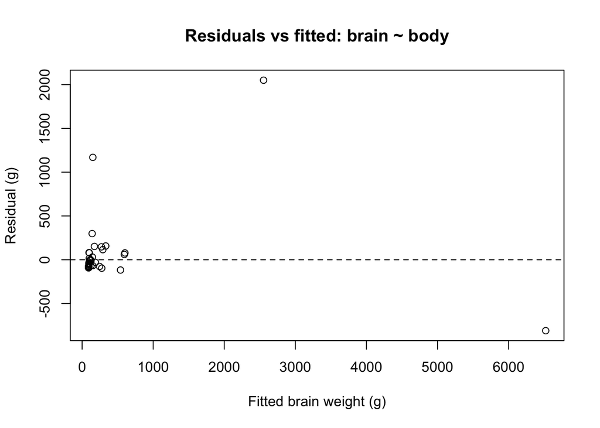

```r
plot(fitted(mod_raw), resid(mod_raw),
     xlab = "Fitted brain weight (g)", ylab = "Residual (g)",
     main = "Residuals vs fitted: brain ~ body")
abline(h = 0, lty = 2)
```

The residuals cluster tightly around zero for small fitted values with a few extreme points, indicating heteroscedasticity (Spread Ratio: 142.829)

## (4b) The log-log scale

```r
m_log <- lm(log(brain) ~ log(body), data = mammals)

b4_coef <- coef(m_log)["log(body)"]            # slope
b4_ci <- confint(m_log, "log(body)")         # 95% CI
b4_rsq <- summary(m_log)$r.squared            # R-squared
b4_sprat <- spread_ratio(m_log)                 # spread ratio

b4_d <- cooks.distance(m_log)
b4_d <- sort(b4_d, decreasing = TRUE)[1]
```

| Statistic | Value |
| --- | --- |
| Slope | 0.752 |
| 95% CI | (0.695, 0.809) |
| R-Squared | 0.921 |
| Spread Ratio | 1.152 |
| Largest Cook’s Distance | 0.122 (Human) |

# Part 5 · The variable you left out (16 points)

## (5a) The average estimates

```r
set.seed(6101)
mod_short <- replicate(2000, {
  z <- rnorm(100)
  x <- 0.6 * z + rnorm(100, 0, 0.8)
  y <- 1 + 1 * x + 2 * z + rnorm(100, 0, 2)
  lm(y ~ x)
}, simplify = FALSE)

mod_long <- replicate(2000, {
  z <- rnorm(100)
  x <- 0.6 * z + rnorm(100, 0, 0.8)
  y <- 1 + 1 * x + 2 * z + rnorm(100, 0, 2)
  lm(y ~ x + z)
}, simplify = FALSE)


coef_short <- sapply(mod_short, function(m) coef(m)["x"])
coef_long  <- sapply(mod_long,  function(m) coef(m)["x"])

mean(coef_short)
```

```
## [1] 2.196386
```

```r
mean(coef_long)
```

```
## [1] 0.9912983
```

Avg estimate coefficient for short model: 2.196

Avg estimate coefficient for long model: 0.991

## (5b) Coverage

```r
covers <- function(m, truth = 1) {
  ci <- confint(m, "x")
  ci[1] <= truth && truth <= ci[2]
}

cover_short <- mean(sapply(mod_short, covers))
cover_long  <- mean(sapply(mod_long,  covers))

cover_short
```

```
## [1] 0.005
```

```r
cover_long
```

```
## [1] 0.95
```

Coverage for short model: 0.005

Coverage for long model: 0.95

## (5c) Where the error comes from

```r
# Effect of z on y: the coefficient on z in each long model
gamma_hat <- sapply(mod_long, function(m) coef(m)["z"])

# Slope of z on x: regress z on x within each study's own data
delta_hat <- sapply(mod_long, function(m) coef(lm(z ~ x, data = m$model))["x"])

mean(gamma_hat)                      # about 2
```

```
## [1] 1.997469
```

```r
mean(delta_hat)                      # about 0.6
```

```
## [1] 0.5997319
```

```r
bias_sim <- mean(gamma_hat) * mean(delta_hat)   # about 1.2
bias_sim
```

```
## [1] 1.197946
```

```r
bias_tab <- c(from_simulations = bias_sim,
              from_parameters  = 2 * 0.6,
              measured_bias    = mean(coef_short) - 1)
```

| Source | Bias in short-model slope |
| --- | --- |
| From simulations | 1.198 |
| From parameters | 1.2 |
| Measured | 1.196 |

No. The error in the short model is 1.2 and depends on the z’s effect and its relationship to x and not n. With 10,000 observations the standard error would shrink, so the estimates would not cluster around 1, and the CIs would almost always exclude the true value. This is the same problem in 1c. We can’t conclude that lowering `pop15` would increase savings because any omitted variables that are correlated with `pop15` may result in bias. The simulation shows that this bias does not disappear with larger samples. Only measuring the missing variables or experimentally assigning `pop15` could address the problem.

# Part 6 · The report (12 points)

## (6a) The sentence about ddpi

Comparing countries with the same shares of population under 15 and over 75 and the same `dpi`, a 1% increase in `ddpi` is associated with a savings rate that is 0.41% points higher across all 50 countries and 0.61 points higher across the 49 countries excluding Libya. The two estimates differ by about one standard error because Libya, with a growth rate of 16.71 against a next-highest value of 10.23 (median 2.99), has a hat value of 0.531, the largest of the 50 countries, so the size of the association depends on a single country.

## (6b) Two sentences that are wrong

- 1. “A one point increase in `pop15` causes the savings rate to fall by 0.461 points.” This sentences draws a causal relationship when it’s only an association.
- 2. “R-squared = 0.338, so 33.8% of savings is caused by these four variables.” This sentences interprets R-squared as easuring a causal influence of the covariates on savings rate. R-squared shows the amoung of variance explained in y given the covariates as captured in this data set.

# AI disclosure

## Prompt log

https://claude.ai/share/51da05a1-3385-4986-a889-1a2dc9eb8f9e